# l12_en_full

Research Seminar

Week 12: Natural, just like real life

Sergi Martínez

smsoler@clio.uc3m.es | Office hours: Tuesday 10:00–13:00 (by prior email)

## Calendar

- Today (Nov 27):
  - How to write quant results interpretation and conclusions
  - RDD, DiD
  - Tutorials
- Nov 30:
  - Empirical quantitative replication of one paper per group
  - Brief presentation of the result and one (empirical) limitation
  - Prepare our presentations
- Dec 4: Research seminar for real
- Dec 11: Mock exam

## Before warming up:

1. Go to your drafts
2. Identify the paper that’s most similar to yours
3. Go to the paper, the version that has been published. Go to the journal website and look for the replication files. If absent, go to the youngest author’s website
4. If there’s no trace of replication data, go to the second paper that is most similar to yours…
5. Once you’ve identified it, tell me the title of the paper

## To warm-up, let’s continue interpreting results [what matters when]

[interactive chart not shown]

## Let’s continue warming up [what matters when]

[interactive chart not shown]

## Last dance [what matters when]

[interactive chart not shown]

## Your projects

[output not shown]

**The vase theory**: To make a vase you must have seen one before, so copying formats is wise and we stand on the shoulders of giants. The submission should look like an academic article, so look at published articles in your field and follow their structure and conventions.

**Clarity and understandability**: Present your material in the way that maximizes the reader’s understanding.

**The order of the qualitative and quantitative evidence is not relevant**

Remember that we want **stories and ideas** to be conveyed.

**Results that are not statistically significant are perfectly fine** and will have no impact on the grade. What matters is doing things right and doing science right.

## Natural experiments

- Like Randomized Controlled Trials, but without control–so they keep having the same assumptions:

**Assumptions**

| Step | Q | Issue |
| --- | --- | --- |
| Assignment | Is it random? | If there’s no balance due to impl. errors |
| Compliance | Did the T receive the treatment? | **Noncompliance**: ITT $\neq$ treatment |
| Interference | Is there overlap or contamination? | **Spillovers**: SUTVA violation |
| Attrition | Do we see the response (DV) in both groups? | Do we lose ≈ no. of obs in the T and the C groups? |
| **Ethics** | Risks? | Consent? Deception? |

## When we can’t flip a coin

we usually set a cutoff, a cap, a threshold. Somewhere we have to stop:

Vietnam draft:

## Thresholds

[figure not shown]

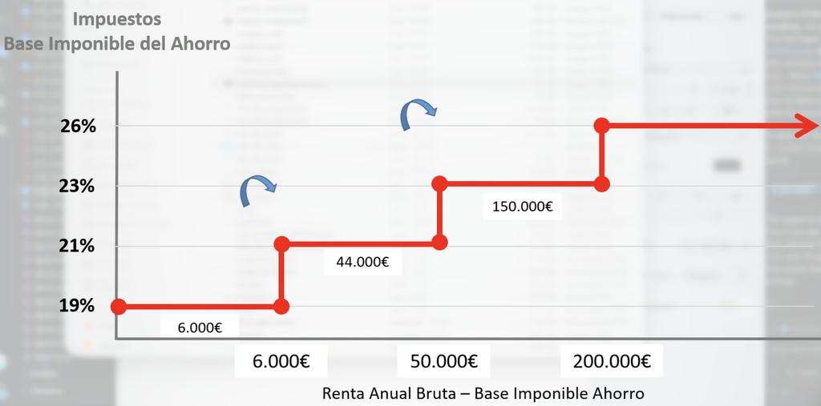

[figure not shown]

[figure not shown]

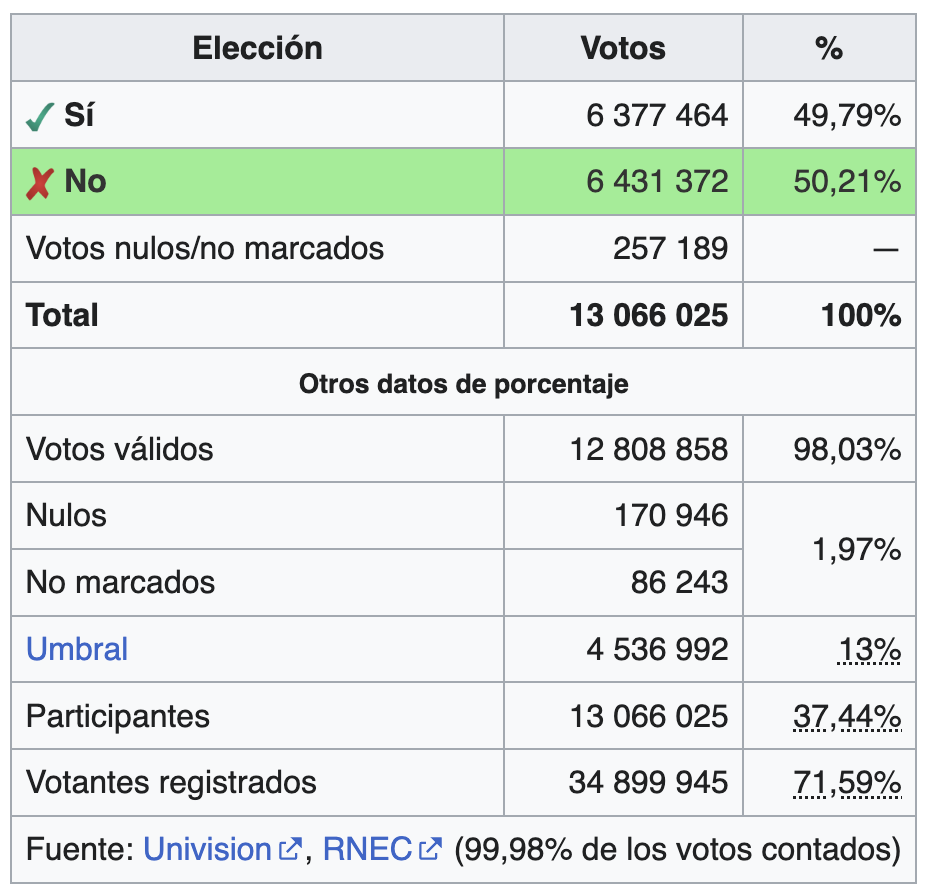

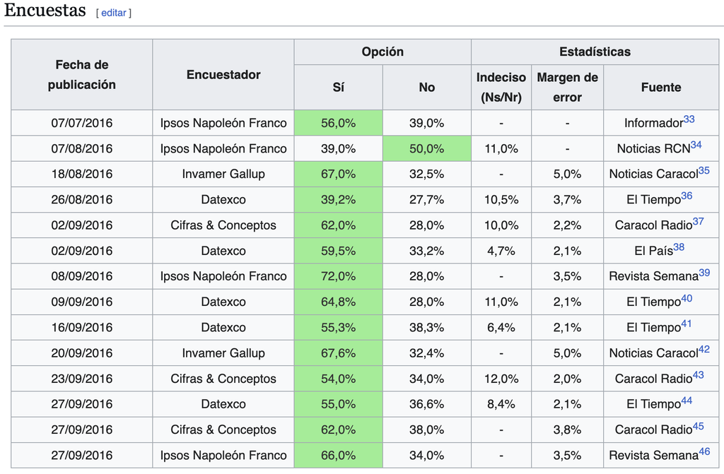

- Credible counterfactuals, at least within certain margins and assumptions

## Aggregation and comparison around a threshold

- We do not compare Colombia having lost and having won, we do not observe the Individual Treatment Effect (ITE)
- We compare how countries that marginally won fared against those that marginally lost, or parties/candidates that won vs. those that lost

*Cattaneo et al*. (2019): “In the RD design, all units have a score, and a treatment is assigned to those units whose value of the score exceeds a known cutoff or threshold, and not assigned to those units whose value of the score is below the cutoff. The key feature of the design is that the probability of receiving the treatment changes abruptly at the known threshold”

**Why?**

Because passing the threshold means being treated. And the probability of being treated or not (control) was practically the same at the margins (49.9 vs. 50.1):

- Which indicates that, within the margins, whether a unit passes the cutoff or not is **random** [Local randomization]
- And that on average they will be very similar, and therefore **good counterfactuals**

## Schrödinger’s declaration

[figure not shown]

## The logic of RDD

- A **running variable** $X$ (a score, a vote share, an age)
- A **cutoff** $c$ that decides treatment: $D = 1$ if $X \geq c$
- Units far from $c$ are not comparable
- Units **just above and just below** $c$ are nearly identical, because landing on either side is largely luck

**Key assumption.** Nothing else jumps at the cutoff, and units cannot precisely manipulate their score to land on the preferred side.

**Sharp RDD**: crossing $c$ always means treatment [You make it to uni or not]

**Fuzzy RDD**: crossing $c$ changes the *probability* of treatment [You pay more taxes on the % $\Delta$ you earn]

## Estimation: compare just above and just below, and focus on the jump

$$Y_i = \alpha + \tau D_i + \beta (X_i - c) + \gamma \, D_i \times (X_i - c) + \varepsilon_i, \quad |X_i - c| \leq h$$

| Term | Meaning |
| --- | --- |
| $\tau$ | **Jump at the cutoff**, the effect we want to estimate |
| $D_i$ | 1 if $X_i \geq c$, 0 otherwise |
| $X_i - c$ | Running variable centered at the cutoff |
| $\beta$, $\gamma$ | Slope below the cutoff and change in slope above |
| $h$ | Bandwidth, the window around $c$ |

Below $c$ the line is $\alpha + \beta(X_i - c)$, and above it is $(\alpha + \tau) + (\beta + \gamma)(X_i - c)$.

## Example: Lee’s (2008) incumbency advantage paper

- **Running variable**: vote margin in US House elections
- **Cutoff**: 0 (win or lose)
- **Outcome**: the past winner wins the next election in that district

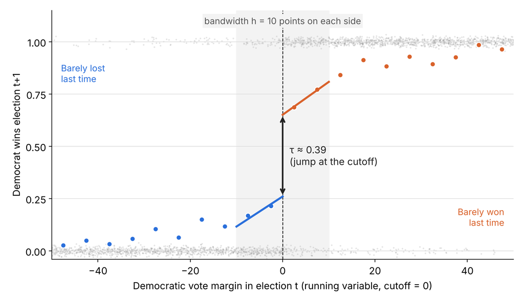

Lee’s estimated jump, with fake data

## Example: Lee (2008)

**Simple way**: Running an interaction

- Dummy equals 0 for obs below the cutoff, 1 above
- Continuous variable …-2, -1, 0, 1, 2…

```r
set.seed(23)
n      <- 2500
margin <- runif(n, -50, 50)                  # Democratic margin in election t
g      <- plogis(margin / 15)
p      <- ifelse(margin < 0, 0.54 * g, 0.67 + 0.66 * (g - 0.5))

df <- data.frame(
  margin         = margin,
  win_next       = rbinom(n, 1, p),          # Democrat wins election t+1
  prev_dem_share = 50 + 0.3 * margin + rnorm(n, 0, 8)  # pre-treatment covariate
)

cutoff <- 0
h      <- 10
df$D   <- as.numeric(df$margin >= cutoff)    # treatment: barely won
df$xc  <- df$margin - cutoff                 # centered running variable

fit <- lm(win_next ~ D * xc, data = subset(df, abs(xc) <= h))
tau <- coef(fit)["D"]    # tau: jump at the cutoff
summary(fit)$coefficients
```

```
               Estimate  Std. Error   t value     Pr(>|t|)
(Intercept)  0.14804152 0.052587369  2.815154 5.084224e-03
D            0.51975410 0.078929518  6.585041 1.241673e-10
xc          -0.01054706 0.009465522 -1.114260 2.657481e-01
D:xc         0.01840151 0.013710623  1.342136 1.802126e-01
```

- Cont.: is the slope below the cutoff
- Cont. x Dummy is the change in the slope after the cutoff
- Dummy is the **jump at the cutoff**

**Easy way**: rdrobust (Cataneo, Titiunik, et al.)

```r
# Same model as the regression above (local linear, same h, no kernel weights)
rd_same <- rdrobust(df$win_next, df$margin, c = cutoff, p = 1, h = h, kernel = "uniform")
rd_same$coef[1]    # equals tau
```

```
[1] 0.5197541
```

```r
# Default call, data-driven bandwidth and robust confidence interval
rd <- rdrobust(df$win_next, df$margin, c = cutoff)
summary(rd)
```

```
Call: rdrobust

Sharp RD estimates using local polynomial regression.

Number of Obs.                 2500
BW type                       mserd
Kernel                   Triangular
VCE method                       NN

                               Left        Right
Number of Obs.                 1231         1269
Eff. Number of Obs.             402          401
Order est. (p)                    1            1
Order bias (q)                    2            2
BW est. (h)                  16.200       16.200
BW bias (b)                  24.985       24.985
rho (h/b)                     0.648        0.648
Unique Obs.                    1231         1269

=====================================================================
                   Point    Robust Inference
                Estimate         z     P>|z|      [ 95% C.I. ]
---------------------------------------------------------------------
     RD Effect     0.480     5.825     0.000     [0.327 , 0.659]
=====================================================================
```

## We can also plot it

```r
rdplot(df$win_next, df$margin, c = cutoff, p = 1,
       x.label = "Democratic margin in election t",
       y.label = "Democrat wins election t+1")
```

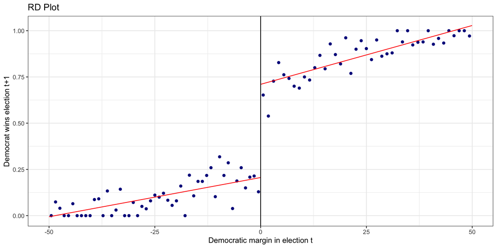

## What could we find?

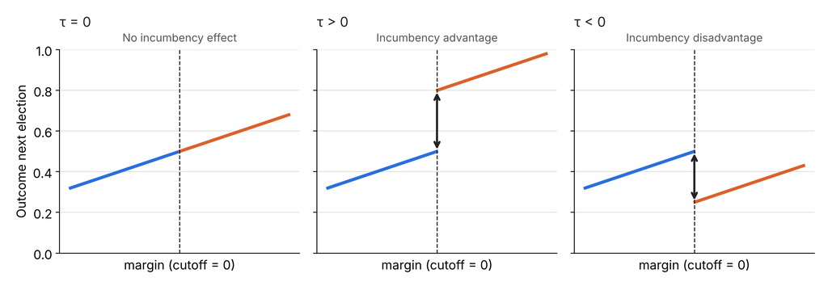

- **No jump**: winning narrowly changes nothing
- **Upward jump**: incumbency helps (what Lee finds)
- **Downward jump**: incumbency hurts, for example through voter fatigue

## Another example: Allinger (2026)

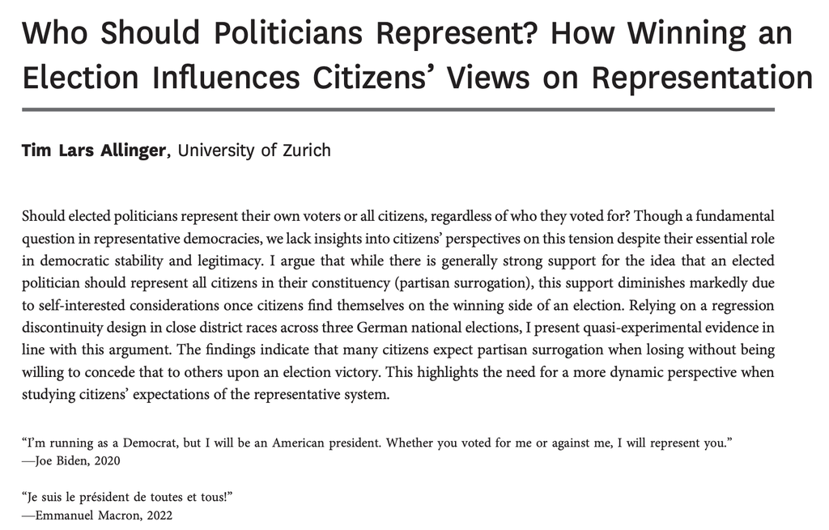

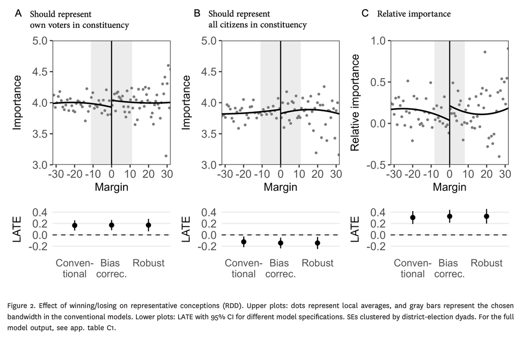

## Another example: Abou Chadi et al.

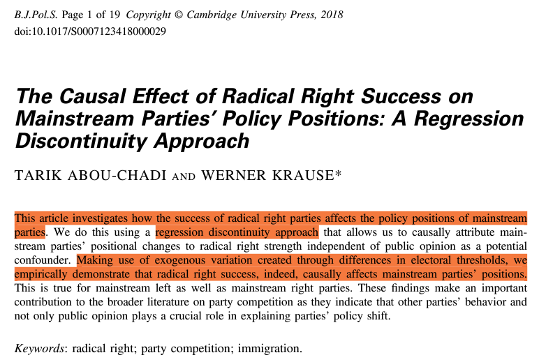

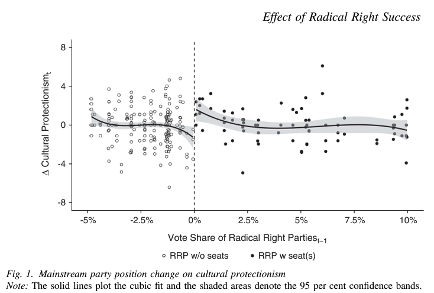

## An extension: Valentim (2021)

[figure not shown]

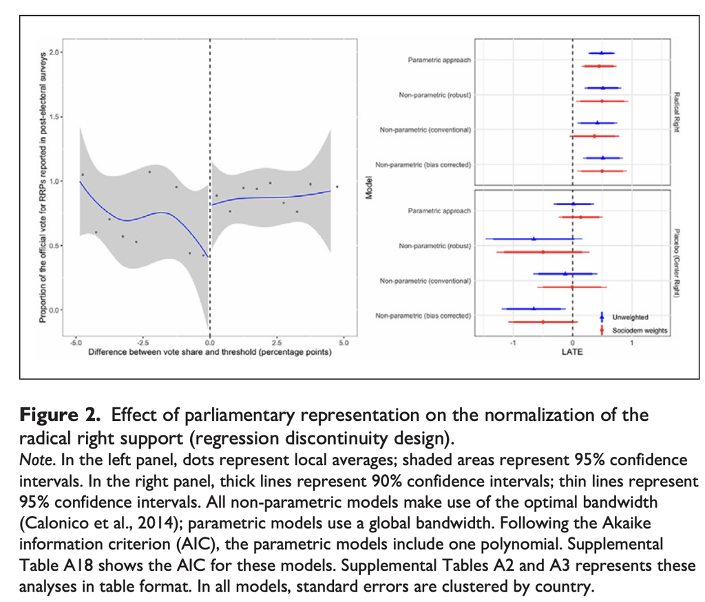

## Aside: Valentim’s conclusion

[interactive chart not shown]

## Example: Querubín et al.

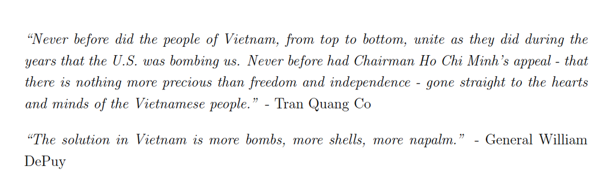

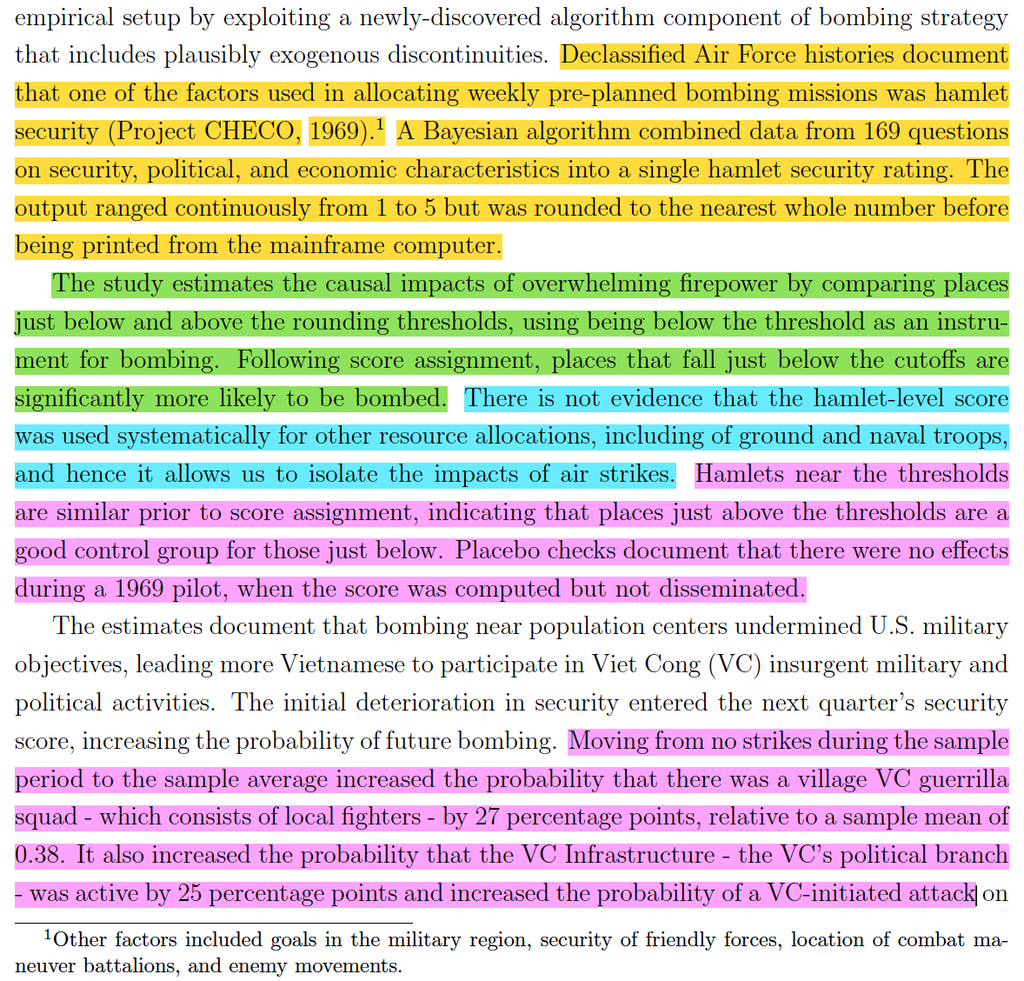

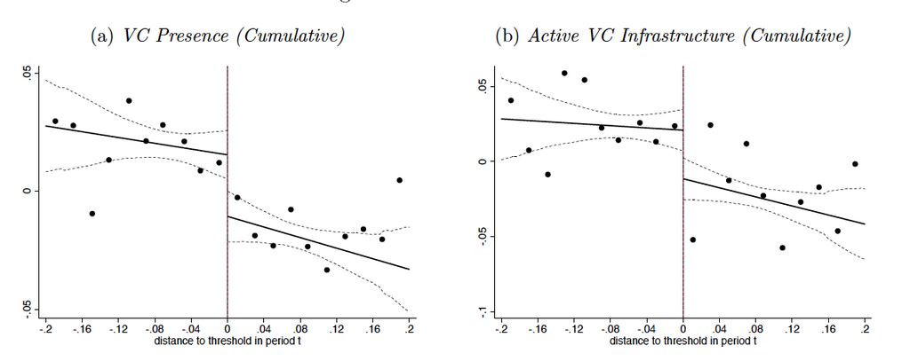

## Example with G3’s project

**1. Build the running variable**

For each country-year in the WVS, code whether left-wing parties won or lost the election, and by what margin.

$$M_{ct} = V^{left}_{ct} - V^{rival}_{ct}$$

Winning is $M_{ct} \geq 0$, losing is $M_{ct} < 0$.

**2. Compare citizens around the cutoff**

Keep country-years with narrow margins and test whether respondents move with their government on support for human rights at the international level.

**3. Estimate**

$$Y_{ict} = \alpha + \tau \,\mathbb{1}[M_{ct} \geq 0] + f(M_{ct}) + \varepsilon_{ict}$$

- $Y_{ict}$: support for international human rights, respondent $i$ in country $c$, year $t$
- $\tau$: effect of a left government on public opinion
- $f(\cdot)$: flexible function of the margin, estimated locally on each side of 0

**Identification**

Near the cutoff, who wins is as good as random. A jump in $Y$ at 0 means citizens follow their government.

## Warning: Not everything is a threshold

A few years ago some students researchers…

- Thresholds have to be real:
  - They have to trigger a substantial jump in the prob (fuzzy) or literally shift treatment status (from 0 to 1) [IT HAS TO JUMP!]
  - If it doesn’t break, it’s not an RDD

[interactive chart not shown]

## Warning II: Assumptions and possible problems

- Assumption: Sorting [who wants to pay more taxes?], which makes us see more observations (quantity) on one side, indicating that some units (quality) can avoid *randomness*
- Possible biases:
  - Omitted variable bias
  - Reverse causality
  - All the other problems of regression because, remember, this is just a quasi-experiment

## Example

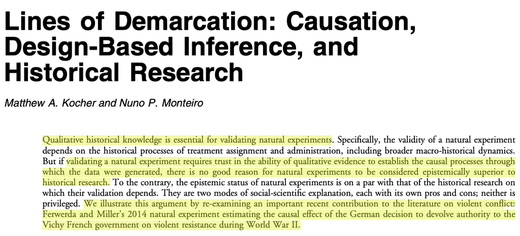

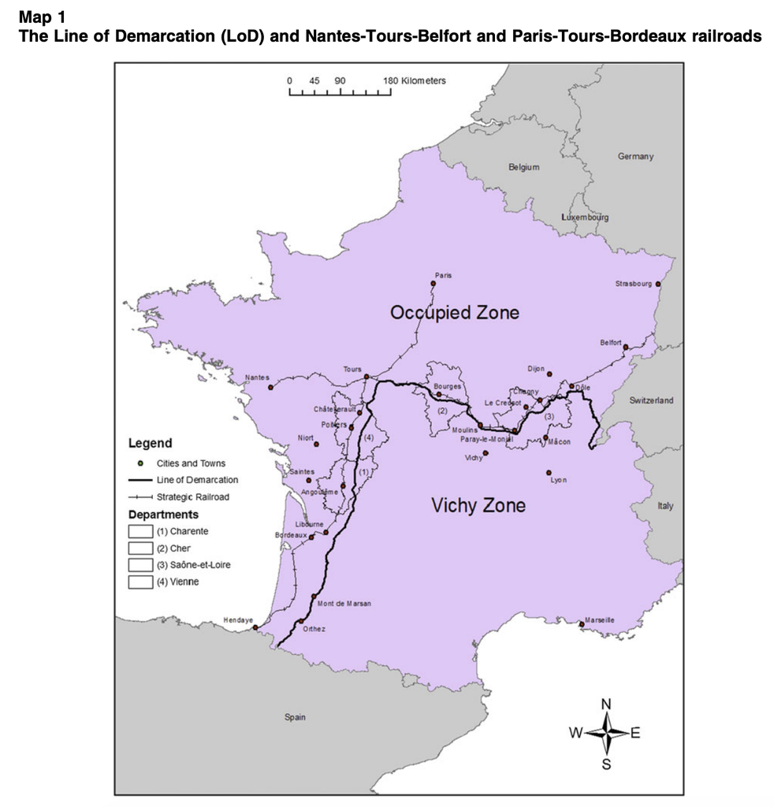

## One more question

Can time be a running variable?

[video not shown]

El sueño va sobre el tiempo

Flotando como un velero, flotando como un velero

Nadie puede abrir semillas

En el corazón del sueño, en el corazón del sueño

Y si el sueño finge muros

En la llanura del tiempo, en la llanura del tiempo

El tiempo le hace creer

Que nace en aquel momento, que nace en aquel momento

## Unexpected events during survey designs

[figure not shown]

## Example: Ares and Hernández

[interactive chart not shown]

Fundamental problem of causal inference: We only observe people in one status (T - C, After - Before)

## In other words

[figure not shown]

## Time (and panel data) allows us to double the counterfactuals

Control - Treated x Before - After

[figure not shown]

[figure not shown]

- We can compare Kontrol G with the one who DiD meet that person before…

## Claudia Goldin

[figure not shown]

## Difference-in-Differences

Estimate the change in trend, aka the difference between trends [before and after] across groups.

Minimum ingredients:

- Panel data: same obs. [the unit of analysis can be aggregated a bit for this] before and after the treatment [we know which obs. are T and which are C]

**Estimation**: $(E[Y(1)|D=1] - E[Y(1)|D=0]) - (E[Y(0)|D=1] - E[Y(0)|D=0])$

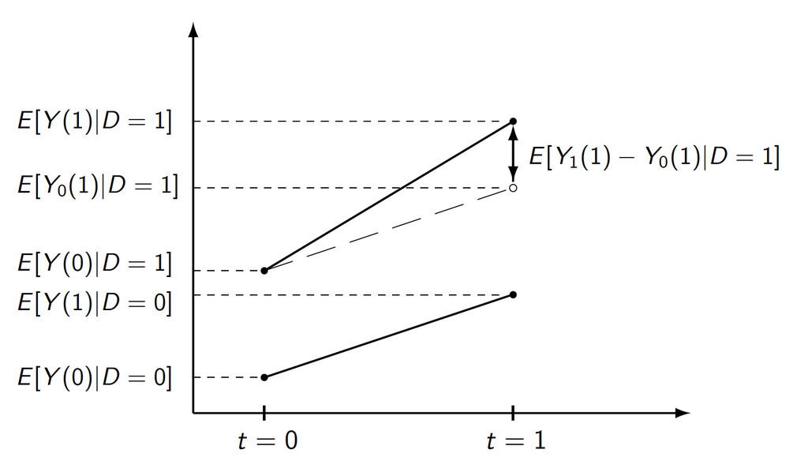

What’s the main assumption?

- That trends would have continued in a parallel way. How do we test this?
- Wait, but we can’t test this.
- The closest we can get is looking backwards to assess whether both groups evolved in parallel before the treatment was administered

## THE EXAMPLE: Card and Krueger

**What does economic theory say about the minimum wage?**

- Abstract
- Map
- DiD 1
- DiD 2
- Assumption 1
- Assumption 2

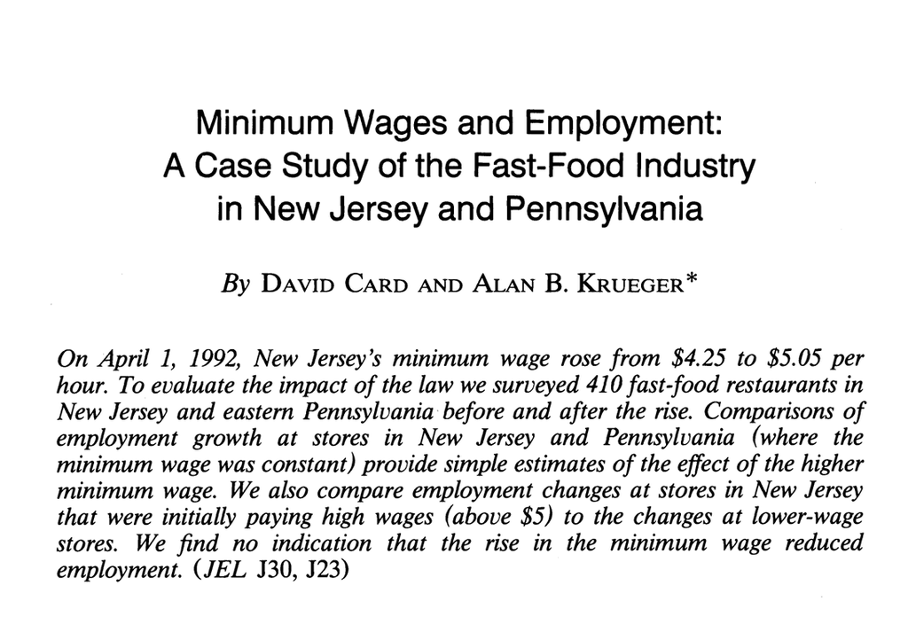

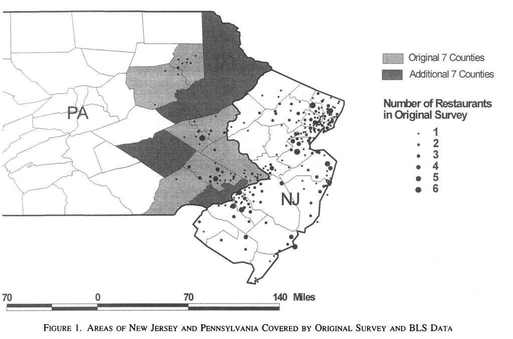

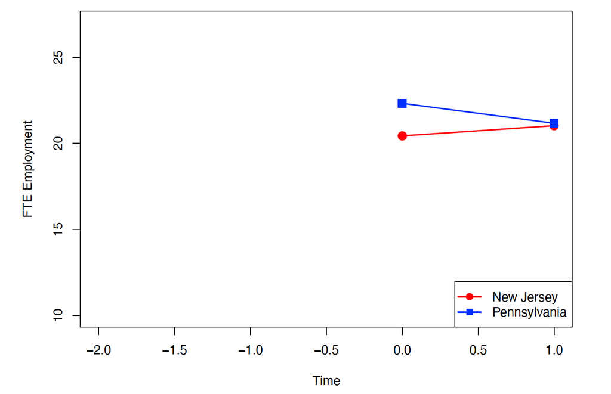

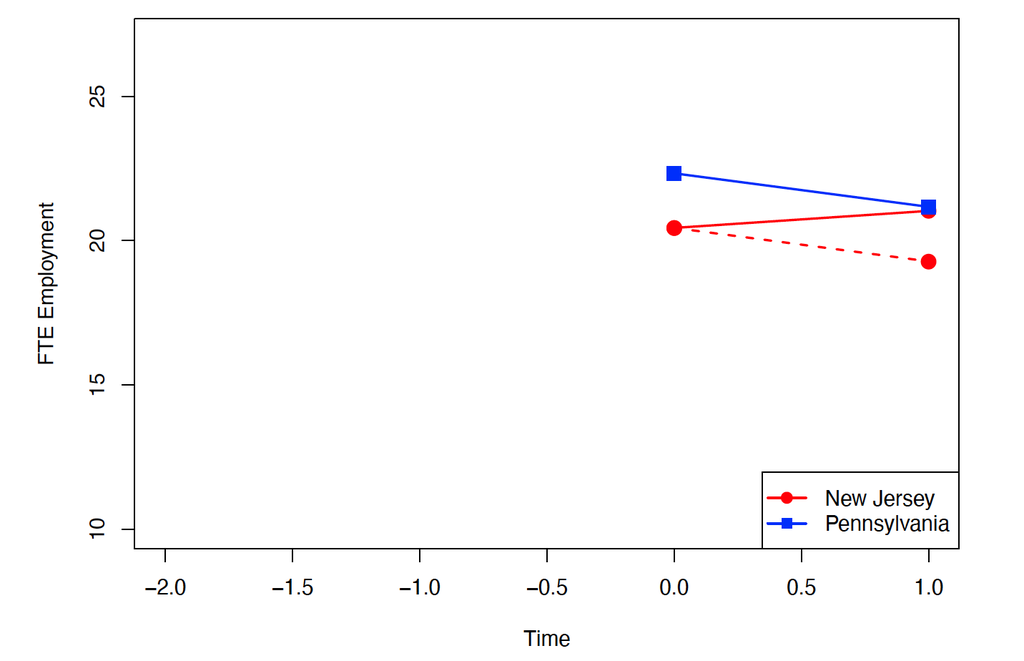

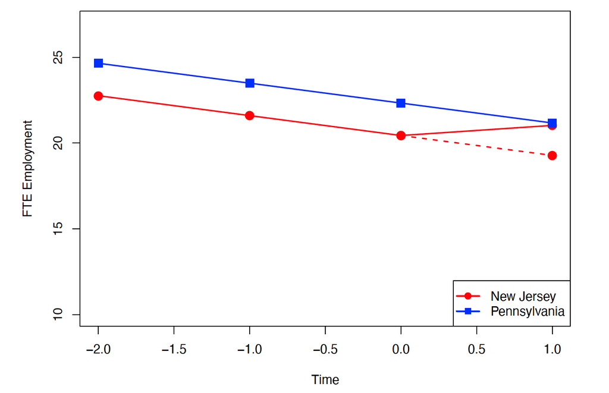

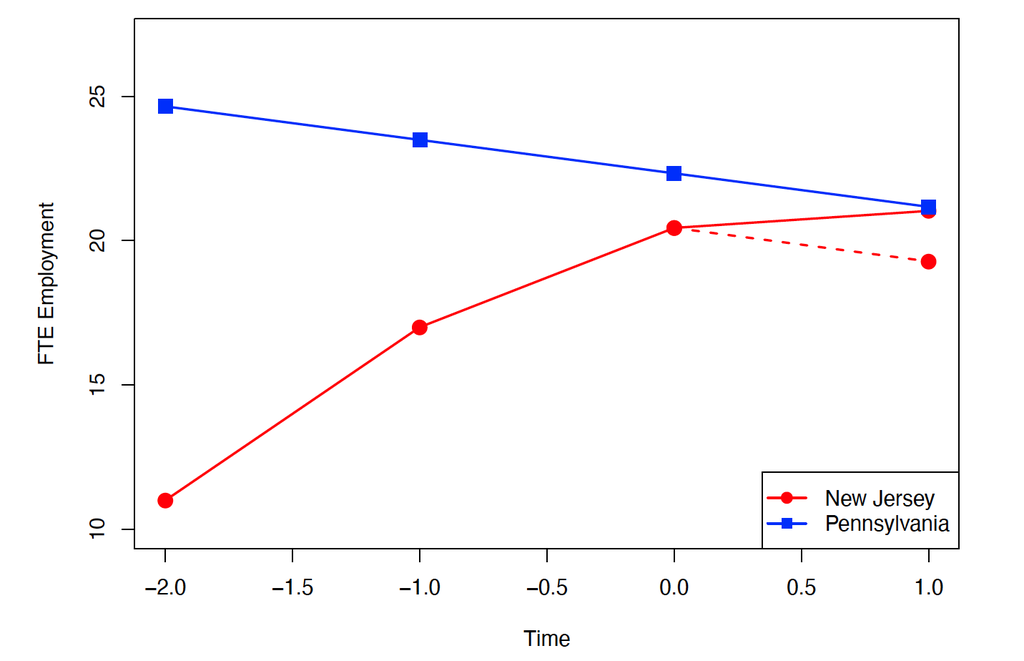